# EDA Visualization with Matplotlib and Seaborn

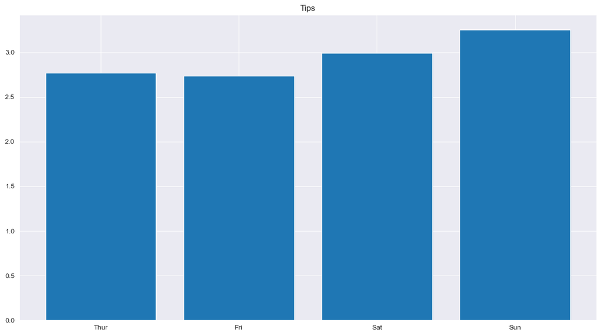

```python
plt.bar(tipz.index, tipz.tip);
plt.title('Tips');
```

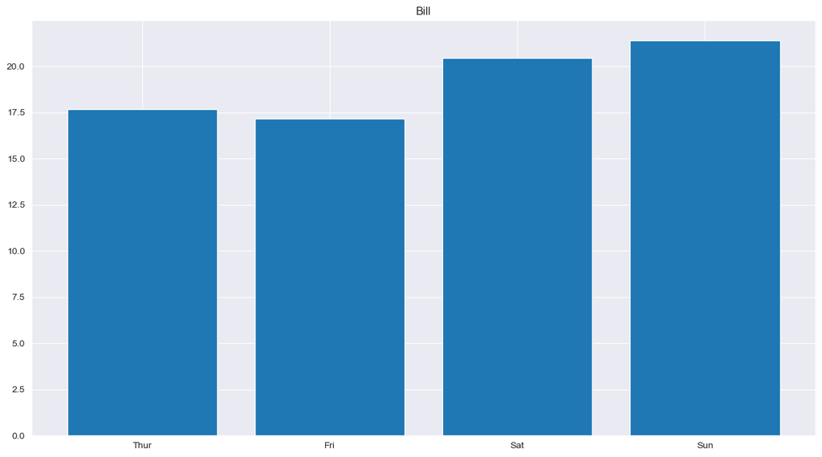

```python
plt.bar(avgbill.index, avgbill.total_bill );
plt.title('Bill')
```

To draw a bar chart to visualize how the average bill amount varies across different days of the week. one way to do this is to compute the day-wise averages and then use plt.bar

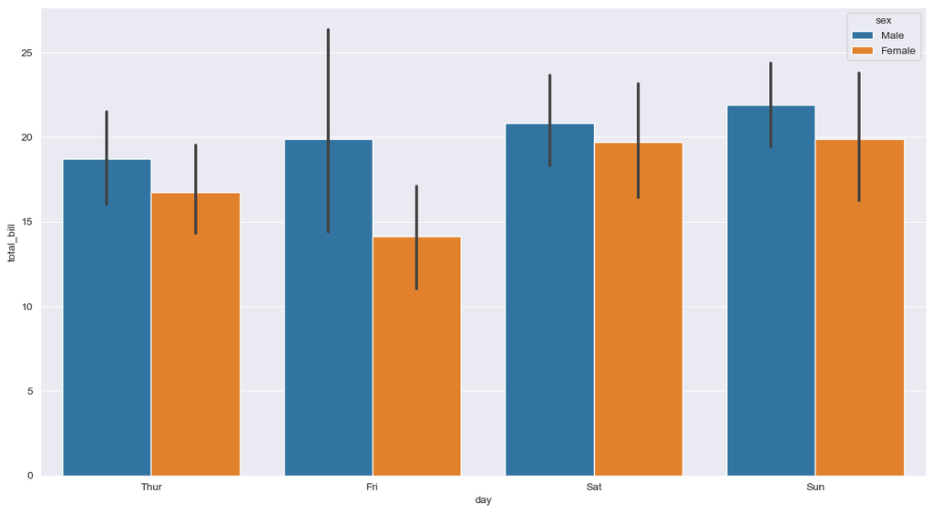

```python
#SEX
sns.barplot(x = 'day', y = 'total_bill', hue = 'sex', data = tips);
```

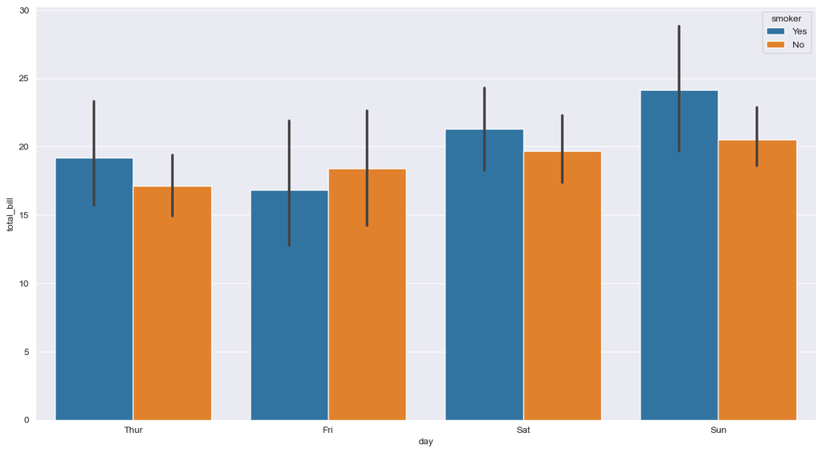

```python
## SMOKERS

sns.barplot(x = 'day', y = 'total_bill', hue = 'smoker', data = tips);
```

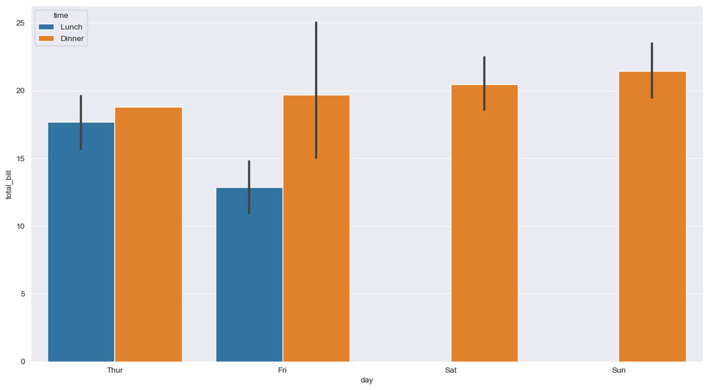

```python
#TIME
sns.barplot(x = 'day', y = 'total_bill', hue ='time', data = tips);
```

Heat map; It is used for a two dimentional data like a matrix or a table using colors. The best way to understand it is by looking at an example. using flight data set from seaborn to visualize monthly passengers footfall at an airport over 12yrs.

```python
import seaborn as sns
```

```python
flights = sns.load_dataset('flights')
flights
```

|  | year | month | passengers |
| --- | --- | --- | --- |
| 0 | 1949 | Jan | 112 |
| 1 | 1949 | Feb | 118 |
| 2 | 1949 | Mar | 132 |
| 3 | 1949 | Apr | 129 |
| 4 | 1949 | May | 121 |
| ... | ... | ... | ... |
| 139 | 1960 | Aug | 606 |
| 140 | 1960 | Sep | 508 |
| 141 | 1960 | Oct | 461 |
| 142 | 1960 | Nov | 390 |
| 143 | 1960 | Dec | 432 |

144 rows × 3 columns

looking at the trend

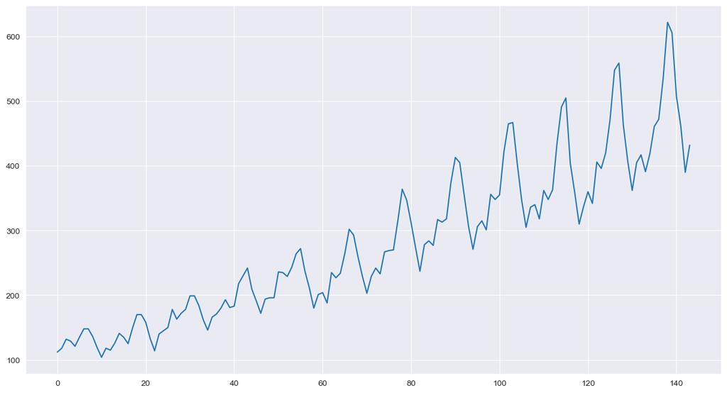

```python
plt.plot(flights.passengers);
```

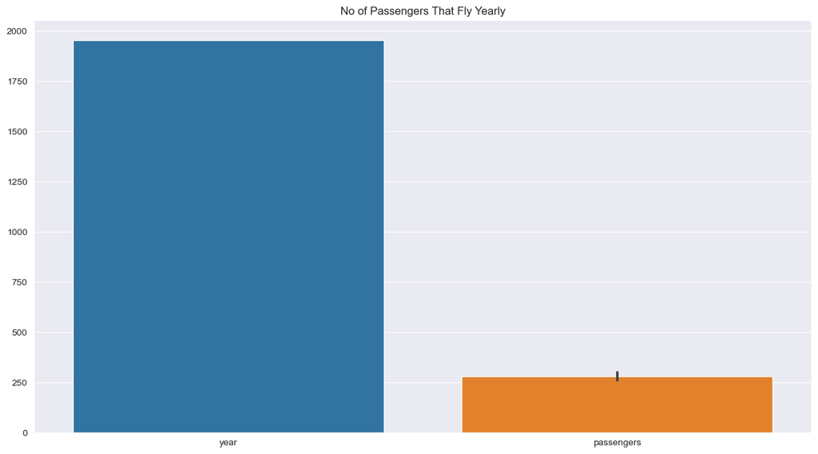

```python
sns.barplot(flights);
plt.title('No of Passengers That Fly Yearly');
```

To represent the data as a heatmap you have to first represent the data as a matrix. Using a pivot method on the data frame, and it will put the data in a kind of matrix format.

```python
flights = sns.load_dataset('flights')
flights = flights.pivot(index = 'month', columns='year', values='passengers')
flights
```

| year month | 1949 | 1950 | 1951 | 1952 | 1953 | 1954 | 1955 | 1956 | 1957 | 1958 | 1959 | 1960 |
| --- | --- | --- | --- | --- | --- | --- | --- | --- | --- | --- | --- | --- |
| Jan | 112 | 115 | 145 | 171 | 196 | 204 | 242 | 284 | 315 | 340 | 360 | 417 |
| Feb | 118 | 126 | 150 | 180 | 196 | 188 | 233 | 277 | 301 | 318 | 342 | 391 |
| Mar | 132 | 141 | 178 | 193 | 236 | 235 | 267 | 317 | 356 | 362 | 406 | 419 |
| Apr | 129 | 135 | 163 | 181 | 235 | 227 | 269 | 313 | 348 | 348 | 396 | 461 |
| May | 121 | 125 | 172 | 183 | 229 | 234 | 270 | 318 | 355 | 363 | 420 | 472 |
| Jun | 135 | 149 | 178 | 218 | 243 | 264 | 315 | 374 | 422 | 435 | 472 | 535 |
| Jul | 148 | 170 | 199 | 230 | 264 | 302 | 364 | 413 | 465 | 491 | 548 | 622 |
| Aug | 148 | 170 | 199 | 242 | 272 | 293 | 347 | 405 | 467 | 505 | 559 | 606 |
| Sep | 136 | 158 | 184 | 209 | 237 | 259 | 312 | 355 | 404 | 404 | 463 | 508 |
| Oct | 119 | 133 | 162 | 191 | 211 | 229 | 274 | 306 | 347 | 359 | 407 | 461 |
| Nov | 104 | 114 | 146 | 172 | 180 | 203 | 237 | 271 | 305 | 310 | 362 | 390 |
| Dec | 118 | 140 | 166 | 194 | 201 | 229 | 278 | 306 | 336 | 337 | 405 | 432 |

The data above shows how passengers were flying monthly every year.

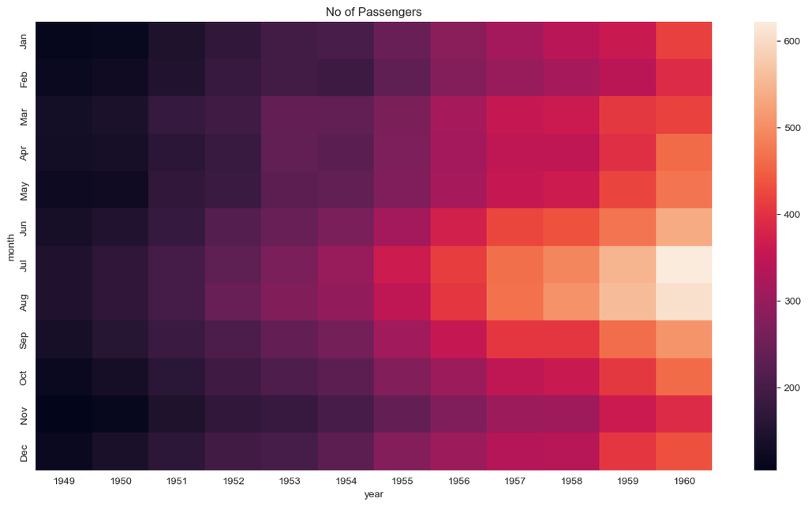

```python
sns.heatmap(flights);
plt.title('No of Passengers');
```

Interpretation: The darker the number the less passengers and the lighter the numbers the higher the passengers that fly. Passengers tend to fly more in July and August. The number of passengers flying yeary tend to grow year by year.

Styling the heat map

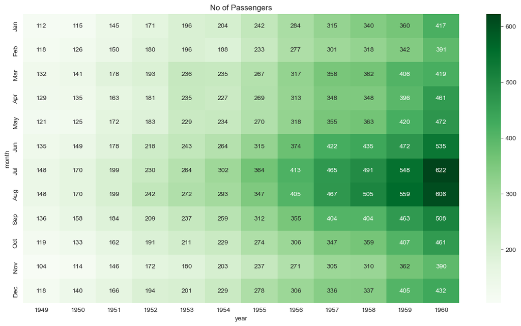

```python
sns.heatmap(flights, fmt = 'd', annot = True, cmap = 'Greens');
plt.title('No of Passengers');
```

# Ploting Multiple Charts in a Grid

Matplotlib and seaborn supports multiple chars in a grid, using plt.subplots which returns a set of axis that can be used for plotting.

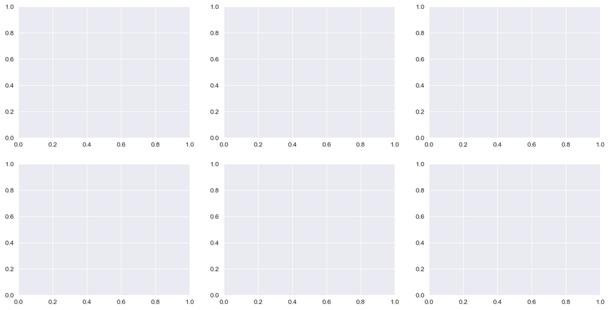

```python
fig, axes = plt.subplots(2, 3, figsize = (16, 8))
```

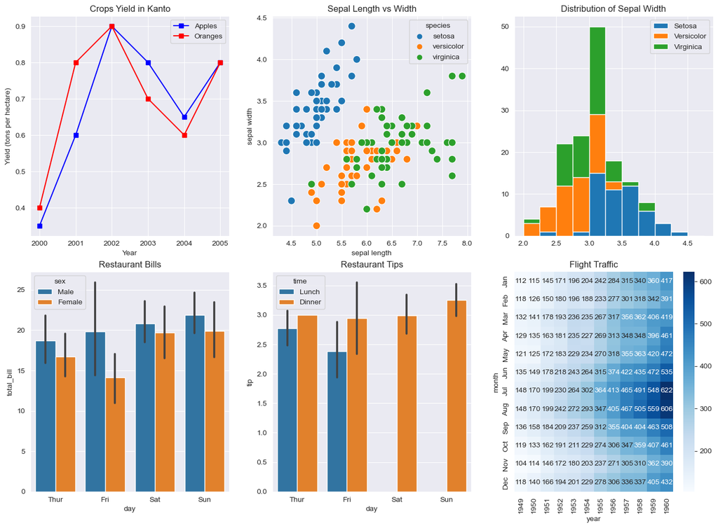

```python
fig, axes = plt.subplots(2, 3, figsize = (14, 10))  #making the subplots

plt.tight_layout(pad=3)   #space between each grid

#using the axis for plotting


#Axes 0 Crops
axes[0, 0].plot(years, apples, 's-b');
axes[0, 0].plot(years, oranges, 's-r');
axes[0, 0].set_xlabel('Year')   # specific in matplotlip
axes[0, 0].set_ylabel('Yield (tons per hectare)');  #specific in matplotlib
axes[0, 0].legend(['Apples', 'Oranges']);
axes[0, 0].set_title('Crops Yield in Kanto');



#plot the axes to seaborn
sns.scatterplot(x='sepal length', y='sepal width', data = flowers,
               hue = 'species',
                s= 100, ax =axes[0,1]);
axes[0, 1].set_title('Sepal Length vs Width');


#the ax=axes[0, 1] is always specified inside sns
#for matplotlib you can directly call the function directly e.g axes[0, 0].plot(years, apples, 's-b');
#plt.title('Sepal Length vs Width')  #sns is still correct.


#use the axis for ploting ---matplotlib
axes[0, 2].set_title('Distribution of Sepal Width')
axes[0, 2].hist([setosa['sepal width'], versicolor['sepal width'], virginica['sepal width']],
               bins = np.arange(2, 5, 0.25), stacked = True);

axes[0, 2].legend(['Setosa', 'Versicolor', 'Virginica']);



#plot the axes to seaborn

axes[1, 0].set_title('Restaurant Bills')
sns.barplot(x = 'day', y ='total_bill', hue = 'sex', data=tips, ax=axes[1, 0]);


#plot the axes into seaborn
axes[1, 1].set_title('Restaurant Tips')
sns.barplot(x = 'day', y ='tip', hue = 'time', data=tips, ax=axes[1, 1]);

#plot the axes into seaborn
axes[1, 2].set_title('Flight Traffic')
sns.heatmap(flights, cmap = 'Blues', fmt = 'd', annot = True, ax=axes[1,2]);
```